# Investigating the Importance of RXDs to a Patient’s LDL Cholesterol

# 1 Setup and Data Ingest

## 1.1 Initial Setup and Package Loads in R

In this section, we load the packages that we will use for study 2.

```r
library(knitr)
library(rmdformats)
library(rmarkdown)
library(GGally)
library(patchwork)
library(car)
library(equatiomatic)
library(janitor)
library(magrittr)
library(mosaic)
library(naniar)
library(simputation)
library(broom)
library(tidyverse)

library(nhanesA)

## Global options
opts_chunk$set(comment=NA)
opts_knit$set(width=75)
theme_set(theme_bw())
options(dplyr.summarise.inform = FALSE)
```

## 1.2 Loading the Raw Data into R

To begin, we import our data and only keep the necessary variables needed for the study.

```r
# raw data
ldl <- nhanes('P_TRIGLY') |> tibble() |> clean_names()
demo <- nhanes('P_DEMO') |> tibble() |> clean_names()
meds <- nhanes('P_RXQ_RX') |> tibble() |> clean_names()
weight <- nhanes('P_WHQ') |> tibble() |> clean_names()
alc <- nhanes('P_ALQ') |> tibble() |> clean_names()
smoke <- nhanes('P_SMQ') |> tibble() |> clean_names()

# get needed data and filter out those
ldl <- ldl |> select(seqn, lbdldl)
demo <- demo |> select(seqn, ridstatr, ridageyr)
meds <- meds |> select(seqn, rxdcount)
alc <- alc |> select(seqn, alq170)
weight <- weight |> select(seqn, whd020)
smoke <- smoke |> select(seqn, smq040)
```

# 2 Cleaning the Data

## 2.1 Merging the Data

With our individual datasets, we will merge them on `seqn` and then only keep unique rows for our dataset.

```r
# join data
new <- left_join(ldl, demo, by = "seqn")
new1 <- left_join(new, meds, by = "seqn")
new2 <- left_join(new1, alc, by = "seqn")
new3 <- left_join(new2, weight, by = "seqn")
new4 <- left_join(new3, smoke, by = "seqn")
study2 <- new4

# see if all seqn values are unique
dim(study2)
```

```
[1] 12956     8
```

```r
length(unique(study2$seqn))
```

```
[1] 5090
```

```r
# keep only distinct rows [some seqn rows repeated]
study2 <- distinct(study2, seqn, .keep_all = TRUE)

# see if all seqn values are unique
dim(study2)
```

```
[1] 5090    8
```

```r
length(unique(study2$seqn))
```

```
[1] 5090
```

## 2.2 The Raw Data

The `study2` dataset currently has 8 variables and 5,090 subjects. The 8 variables we have provide information on a patient’s unique identifier, their LDL cholesterol, if they were only interviewed or if they were interviewed and MEC examined, their age, the number of prescription medications they are taking, the amount of times in the past 30 days that they had 4-5+ drinks on an occasion, their weight, and their current smoking status.

```r
glimpse(study2)
```

```
Rows: 5,090
Columns: 8
$ seqn     <dbl> 109264, 109271, 109274, 109277, 109282, 109286, 109290, 10929…
$ lbdldl   <dbl> 86, 97, 49, 64, 164, 131, 105, 102, 123, 127, NA, 93, 154, 12…
$ ridstatr <dbl> 2, 2, 2, 2, 2, 2, 2, 2, 2, 2, 2, 2, 2, 2, 2, 2, 2, 2, 2, 2, 2…
$ ridageyr <dbl> 13, 49, 68, 12, 76, 33, 68, 58, 30, 54, 55, 47, 63, 28, 45, 2…
$ rxdcount <dbl> NA, 3, 7, NA, 6, 1, 4, 8, NA, NA, NA, NA, 2, 1, NA, NA, 10, N…
$ alq170   <dbl> NA, NA, 0, NA, NA, 0, NA, NA, 0, NA, 0, 0, 0, 10, NA, 1, 0, N…
$ whd020   <dbl> NA, 222, 219, NA, 185, 142, 155, 185, 120, 130, 148, 150, 168…
$ smq040   <dbl> NA, 1, NA, NA, 3, NA, NA, NA, NA, NA, NA, 3, NA, 3, NA, 3, NA…
```

## 2.3 Which variables should be included in the tidy data set?

We will filter our data to only include patient’s who were interviewed and MEC examined (`ridstatr`) and are adults (`ridageyr`), as well as change the type of `smq040` to factor.

```r
# filter adults and only keep ridstatr values of 2
study2 <- study2 |>
  filter(ridstatr == 2) |>
  filter(ridageyr >= 21) |>
  filter(ridageyr < 80)

# factor
study2 <- study2 |> mutate(smq040 = factor(smq040))

study2
```

```
# A tibble: 3,922 × 8
     seqn lbdldl ridstatr ridageyr rxdcount alq170 whd020 smq040
    <dbl>  <dbl>    <dbl>    <dbl>    <dbl>  <dbl>  <dbl> <fct>
 1 109271     97        2       49        3     NA    222 1
 2 109274     49        2       68        7      0    219 <NA>
 3 109282    164        2       76        6     NA    185 3
 4 109286    131        2       33        1      0    142 <NA>
 5 109290    105        2       68        4     NA    155 <NA>
 6 109292    102        2       58        8     NA    185 <NA>
 7 109297    123        2       30       NA      0    120 <NA>
 8 109300    127        2       54       NA     NA    130 <NA>
 9 109305     NA        2       55       NA      0    148 <NA>
10 109307     93        2       47       NA      0    150 3
# … with 3,912 more rows
```

For my study 2 model, the variables that I am going to use are `rxdcount`, `alq170`, `whd020`, and `smq040` to predict a patient’s `lbdldl`. The other three variables, `seqn`, `ridstatr`, and `ridageyr`, are in the dataset so that we could merge datasets together and then only keep adult patients who were both interviewed and examined.

## 2.4 Checking our Outcome and Key Predictor

Our most important variables in this study are `lbdldl` and `rxdcount`, so we will look at a quick numerical summary of each.

```r
df_stats(~ lbdldl + rxdcount, data = study2)
```

```
  response min Q1 median  Q3 max     mean        sd    n missing
1   lbdldl   7 85    106 130 357 109.4954 35.646295 3601     321
2 rxdcount   1  1      3   5  22   3.8662  3.082779 2287    1635
```

From this summary, we can see that there are 321 missing values for our outcome variables `lbdldl` and 1,635 missing values for our key predictor `rxdcount`. As we will see later, we will just be using complete cases for our final dataset. Furthermore, all values in the dataset are feasible.

## 2.5 Checking the Quantitative Predictors

We also have two other predictor variables that are quantitative that we have to look at.

```r
df_stats(~ alq170 + whd020, data = study2)
```

```
  response min  Q1 median  Q3  max      mean        sd    n missing
1   alq170   0   0      0   1  999  15.64188  114.2757 2636    1286
2   whd020  77 150    178 214 9999 350.94136 1259.3717 3922       0
```

We can see that we have 1,286 missing values for `alq170` and no missing values for `whd020`. As stated before, this doesn’t really matter because of how we will use complete cases. Something to look at is the maximum values for each variable, as these are not very possible (999 for `alq170` and 9999 for `whd020`). After looking at the NHANES codebook, we can see that for `alq170`, values of 777 or 999 represent a patient refusing to answer or didn’t know. Similarly for `whd020`, values of 7777 or 9999 represent a patient refusing to answer or didn’t know, so we’ll have to filter out these patients for our dataset.

```r
study2 <- study2 |>
  filter(alq170 != 777 & alq170 != 999) |>
  filter(whd020 != 7777 & whd020 != 9999)

df_stats(~ alq170 + whd020, data = study2)
```

```
  response min  Q1 median  Q3 max       mean        sd    n missing
1   alq170   0   0      0   1  30   1.398355  4.247804 2553       0
2   whd020  77 151    180 212 578 186.160987 49.165962 2553       0
```

After rerunning df_stats(), we can see that we effectively removed patients with uninformative value responses

## 2.6 Checking the Categorical Variables

We also have a categorical predictor `smq040`, which indicates a patient’s smoking status. As such, we have to see if the levels are ordered in a logical way.

```r
levels(study2$smq040)
```

```
[1] "1" "2" "3"
```

```r
study2 |> tabyl(smq040)
```

```
 smq040    n    percent valid_percent
      1  409 0.16020368     0.3483816
      2  150 0.05875441     0.1277683
      3  615 0.24089307     0.5238501
   <NA> 1379 0.54014884            NA
```

levels() helps us see that the smoking categories are in a good order and tabyl() allows us to see the value distribution. We have 1,379 missing values, but again this is irrelevant as we will use complete cases.

## 2.7 Dealing with Missingness and Seeing Our Tidy Dataset

As of right now, we still have patient’s who have missing values across the variables in our tidy data. We will now remove `ridstatr` and `ridageyr` as they were used to keep certain patients.

```r
study2 <- study2 |>
  select(seqn, lbdldl, rxdcount, alq170, whd020, smq040)

study2
```

```
# A tibble: 2,553 × 6
     seqn lbdldl rxdcount alq170 whd020 smq040
    <dbl>  <dbl>    <dbl>  <dbl>  <dbl> <fct>
 1 109274     49        7      0    219 <NA>
 2 109286    131        1      0    142 <NA>
 3 109297    123       NA      0    120 <NA>
 4 109305     NA       NA      0    148 <NA>
 5 109307     93       NA      0    150 3
 6 109313    154        2      0    168 <NA>
 7 109317    120        1     10    195 3
 8 109323     79       NA      1    280 3
 9 109324    108       10      0    150 <NA>
10 109327    113        1      1    140 <NA>
# … with 2,543 more rows
```

We can see that our dataset only holds our relevant study variables now.

### 2.7.1 Tibble of Complete Cases

As stated before we will only keep patients with complete data because we are assuming that the missing values are missing completely at random. As such, we will drop the observations that have some ‘NA’ values.

```r
study2 <- study2 |> filter(complete.cases(study2))

study2
```

```
# A tibble: 630 × 6
     seqn lbdldl rxdcount alq170 whd020 smq040
    <dbl>  <dbl>    <dbl>  <dbl>  <dbl> <fct>
 1 109317    120        1     10    195 3
 2 109330     67        3      0    140 3
 3 109335    109        6      0    220 1
 4 109342    161        5      8    200 1
 5 109379    102       10      0    185 3
 6 109457    125        5      1    222 3
 7 109480    165        2     12    450 1
 8 109571    103        3      2    200 1
 9 109580     54        1      1    147 2
10 109593     93        2      1    148 1
# … with 620 more rows
```

Now that we have our dataset with complete cases, we have to make sure that the values for our variables still satisfy our data requirements.

```r
length(unique(study2$lbdldl))
```

```
[1] 163
```

```r
tabyl(study2$smq040)
```

```
 study2$smq040   n    percent
             1 187 0.29682540
             2  59 0.09365079
             3 384 0.60952381
```

We can see that our data still meets the requirements, as our outcome variable has at least 15 unique values and for our categorical variable, there are three levels and each has more than 30 patients.

# 3 Codebook and Data Description

## 3.1 The Codebook

The NHANES dataset combines interviews and physical examinations from adults and children in the United States using surveys examining a nationally representative sample of about 5,000 persons each year. In my work, we used data from the 2017 - March 2020 survey period, and from the following data sets: Demographics (P-DEMO), LDL Cholesterol (P-TRIGLY), Prescription Medications (P_RXQ_RX), Weight History (P_WHQ), Alcohol Use(P_ALQ), and Smoking - Cigarette Use (P_SMQ). We also restricted the data to adults who were both interviewed and MEC examined and are between 21-79 as we don’t want to include children or the elderly.

| Variable | Type | Description / Levels |
| --- | --- | --- |
| `seqn` | ID | Subject code identifier of patient |
| `lbdldl` | Quantitative | Patient’s LDL-cholesterol (mg/dL) |
| `rxdcount` | Quantitative | Number of prescription medicines taken by patient |
| `alq170` | Quantitative | Number of times in past 30 days patient has had 4-5 drinks on an occasion |
| `whd020` | Quantitative | Patient’s current self-reported weight (pounds) |
| `smq040` | Categorical (3) | Patient’s current smoking status: 1 if every day, 2 if some days, 3 if not at all |

## 3.2 Analytic Tibble

Here we will prove that our data is a tibble and print it out.

```r
is_tibble(study2)
```

```
[1] TRUE
```

```r
study2
```

```
# A tibble: 630 × 6
     seqn lbdldl rxdcount alq170 whd020 smq040
    <dbl>  <dbl>    <dbl>  <dbl>  <dbl> <fct>
 1 109317    120        1     10    195 3
 2 109330     67        3      0    140 3
 3 109335    109        6      0    220 1
 4 109342    161        5      8    200 1
 5 109379    102       10      0    185 3
 6 109457    125        5      1    222 3
 7 109480    165        2     12    450 1
 8 109571    103        3      2    200 1
 9 109580     54        1      1    147 2
10 109593     93        2      1    148 1
# … with 620 more rows
```

## 3.3 Numerical Data Description

With the variables relevant to our study, we will look at some numerical summaries for each.

```r
Hmisc::describe(study2 |> select(-seqn))
```

```
select(study2, -seqn)

 5  Variables      630  Observations
--------------------------------------------------------------------------------
lbdldl
       n  missing distinct     Info     Mean      Gmd      .05      .10
     630        0      163        1    107.3    41.47     54.0     64.0
     .25      .50      .75      .90      .95
    81.0    102.5    128.0    157.0    177.5

lowest :  18  25  30  35  39, highest: 217 219 222 236 297
--------------------------------------------------------------------------------
rxdcount
       n  missing distinct     Info     Mean      Gmd      .05      .10
     630        0       18    0.977    3.973     3.15        1        1
     .25      .50      .75      .90      .95
       2        3        5        8       10

lowest :  1  2  3  4  5, highest: 14 15 16 17 19

Value          1     2     3     4     5     6     7     8     9    10    11
Frequency    139   118    89    72    55    41    38    20    16    22     5
Proportion 0.221 0.187 0.141 0.114 0.087 0.065 0.060 0.032 0.025 0.035 0.008

Value         12    13    14    15    16    17    19
Frequency      6     3     1     2     1     1     1
Proportion 0.010 0.005 0.002 0.003 0.002 0.002 0.002
--------------------------------------------------------------------------------
alq170
       n  missing distinct     Info     Mean      Gmd      .05      .10
     630        0       15    0.665    1.746    3.051        0        0
     .25      .50      .75      .90      .95
       0        0        1        4       10

lowest :  0  1  2  3  4, highest: 12 15 16 20 30

Value          0     1     2     3     4     5     6     7     8    10    12
Frequency    437    61    37    17    23     7     2     4     5     7     3
Proportion 0.694 0.097 0.059 0.027 0.037 0.011 0.003 0.006 0.008 0.011 0.005

Value         15    16    20    30
Frequency      7     1     9    10
Proportion 0.011 0.002 0.014 0.016
--------------------------------------------------------------------------------
whd020
       n  missing distinct     Info     Mean      Gmd      .05      .10
     630        0      162        1    195.2    53.43    130.0    140.0
     .25      .50      .75      .90      .95
   161.0    185.0    220.0    260.0    280.5

lowest :  95 100 105 110 112, highest: 360 380 416 450 457
--------------------------------------------------------------------------------
smq040
       n  missing distinct
     630        0        3

Value          1     2     3
Frequency    187    59   384
Proportion 0.297 0.094 0.610
--------------------------------------------------------------------------------
```

With this summary, we can see that all values are feasible, have a logical level order (if applicable), and have no missing values.

# 4 My Research Question

Our dataset contains adults within the age range of 21-79 and who have complete data on all of our variables. The outcome variable `lbdldl` was chosen because LDL (bad) cholesterol is something that I would like to investigate. The predictor variables `rxdcount`, `alq170`, `whd020`, and `smq040` were chosen because of their relationship to LDL cholesterol. The number of prescription medications is relevant because if a patient is taking more medications, they likely have worse health conditions and there is a higher chance that they are taking medications that may increase LDL cholesterol. Similarly, current weight was chosen because it’s a decent relative indicator of health. Alcohol and smoking use were selected because both have been observed to increase one’s LDL cholesterol.

Our research question:

How accurately can we predict a patient’s LDL cholesterol value with the number of prescription medications they are taking and can we improve our predictions by including some other predictor variables (`alq170`, `whd020`, `smq040`) in our `study2` data?

# 5 Partitioning the Data

To be able to train and test our models, we will use a 70/30 split so that we can train our models with 70% of the data and then test with the remaining 30%.

```r
set.seed(12345)

# take train sample
study_train <- slice_sample(study2, prop = 0.7)
# get the rest of the samples
study_test <- anti_join(study2, study_train, by = "seqn")

# check dimensions
dim(study_train)
```

```
[1] 441   6
```

```r
dim(study_test)
```

```
[1] 189   6
```

The sum of rows of each (441 and 189) totals the number of rows in our dataset so the data was split correctly

# 6 Transforming the Outcome

## 6.1 Visualizing the Outcome Distribution

To see if there are any issues with `LBDLDL` in our training data, we will visualize thee values with box, violin, and QQ plots.

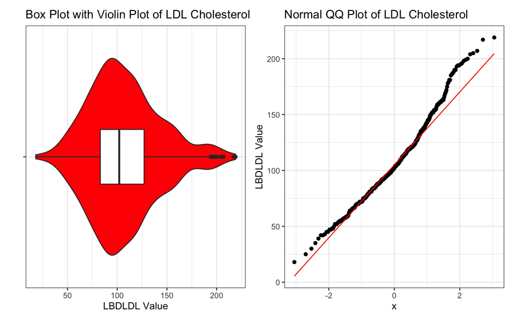

```r
p1 <- ggplot(study_train, aes(x = "", y = lbdldl)) +
  geom_violin(fill = "red") +
  geom_boxplot(width = 0.25) +
  labs(title = "Box Plot with Violin Plot of LDL Cholesterol",
       y = "LBDLDL Value",
       x = "") +
  coord_flip()

p2 <- ggplot(study_train, aes(sample = lbdldl)) +
  geom_qq() +
  geom_qq_line(col = "red") +
  guides(col = "none") +
  theme_bw() +
  labs(y = "LBDLDL Value",
       title = "Normal QQ Plot of LDL Cholesterol")

p1 + p2
```

From the box plot with a violin plot overlay and the QQ plot, we can see that the data has a right skew, so we may have to transform our outcome variable.

## 6.2 `boxCox` function to assess need for transformation of our outcome

Because our train data is right skewed, we want to see if there is a transformation that can make our outcome variable `lbdldl` more normally distributed.

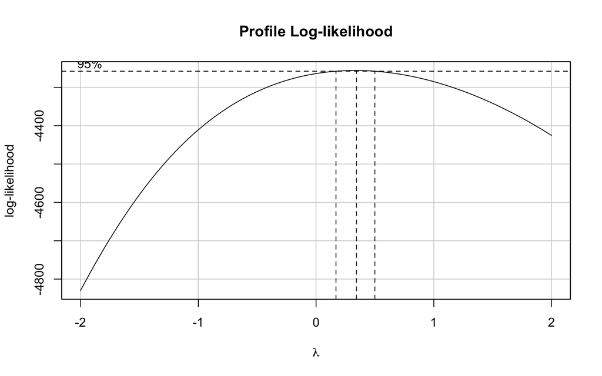

```r
boxCoxMod <- lm(lbdldl ~ rxdcount + alq170 + whd020 + smq040, data = study2)
boxCox(boxCoxMod)
```

```r
powerTransform(boxCoxMod)
```

```
Estimated transformation parameter
       Y1
0.3324712
```

From powerTransform(), the estimated transformation parameter is 0.33, so we will either not transform our outcome or we will use a square root transformation

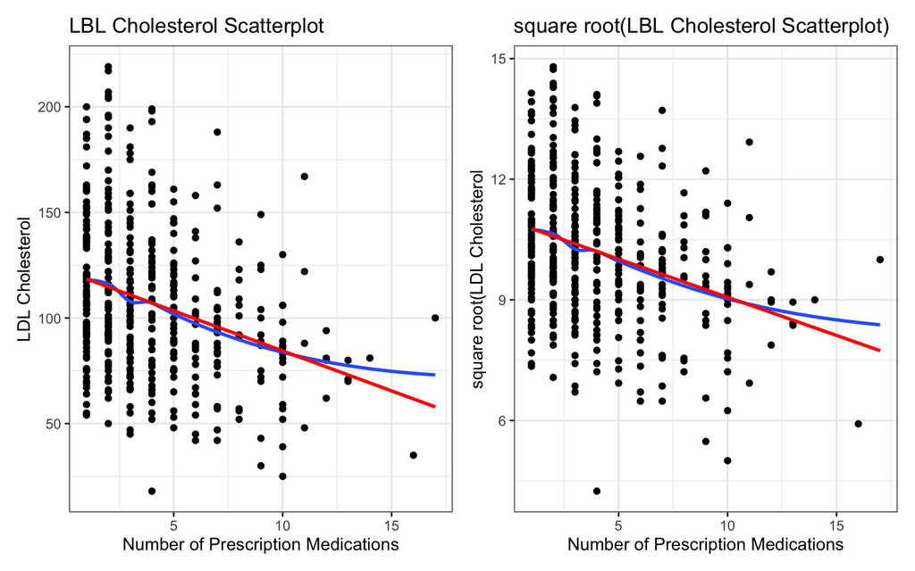

```r
p1 <- ggplot(study_train, aes(x = rxdcount, y = lbdldl)) +
  geom_point() +
  geom_smooth(method = "loess", formula = y ~ x, se = FALSE) +
  geom_smooth(method = "lm", col = "red", formula = y ~ x, se = FALSE) +
  labs(title = "LBL Cholesterol Scatterplot",
       x = "Number of Prescription Medications",
       y = "LDL Cholesterol")

p2 <- ggplot(study_train, aes(x = rxdcount, y = sqrt(lbdldl))) +
  geom_point() +
  geom_smooth(method = "loess", formula = y ~ x, se = FALSE) +
  geom_smooth(method = "lm", col = "red", formula = y ~ x, se = FALSE) +
  labs(title = "square root(LBL Cholesterol Scatterplot)",
       x = "Number of Prescription Medications",
       y = "square root(LDL Cholesterol")

p1 + p2
```

From these two plots, there doesn’t look to be much of a difference whether or not we transform our outcome variable. The loess curve appears to be a bit less curved when using the square root transformation, but nothing too noticeable so we won’t transform our `lbdldl` variable.

## 6.3 Numerical Summaries of the Predictors

Before we build our model, we want to look at the value distribution for each of our predictor variables.

```r
study_train |> select(-seqn, -lbdldl) |>
  mosaic::inspect()
```

```
categorical variables:
    name  class levels   n missing
1 smq040 factor      3 441       0
                                   distribution
1 3 (61%), 1 (30.2%), 2 (8.8%)

quantitative variables:
      name   class min  Q1 median  Q3 max       mean        sd   n missing
1 rxdcount numeric   1   2      3   5  17   4.013605  2.951085 441       0
2   alq170 numeric   0   0      0   1  30   1.922902  5.253436 441       0
3   whd020 numeric  95 165    185 217 457 195.687075 49.824210 441       0
```

As a reminder, we have three quantitative predictor variables (`rxdcount`, `alq170`, `whd020`) and one categorical predictor (`smq040`).

## 6.4 Scatterplot Matrix and Collinearity Check

A scatterplot matrix can also be utilized to help us see the relationship between our outcome and predictor variables.

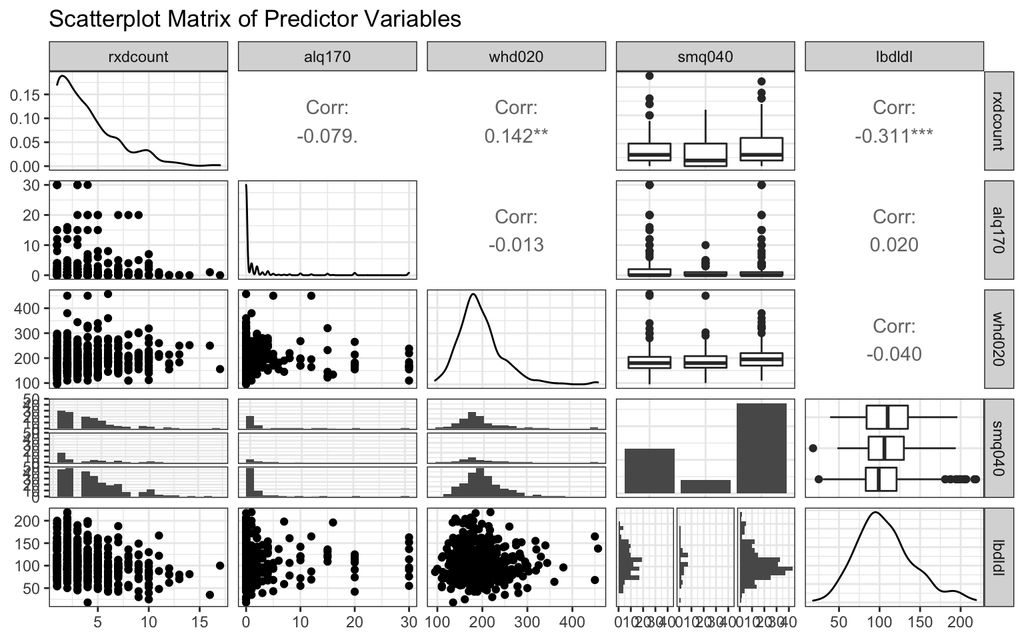

```r
temp_data <- study_train |>
  select(rxdcount, alq170, whd020, smq040, lbdldl)

ggpairs(temp_data, title = "Scatterplot Matrix of Predictor Variables",
        lower = list(combo = wrap("facethist", bins = 20)))
```

From the scatterplot matrix, we are able to look at a quick overview of the relationships between variables. What we are particularly interested in is the relations between `lbdldl` and the quantitative predictor variables of `rxdcount`, `alq170`, and `whd020`. We can see that `lbdldl` isn’t highly correlated with any of our quantitative predictors, with the highest being -0.311. We can also see that `rxdcount` and `alq170` are right skewed, which makes sense because there is a low probability of one having a higher value for these variables.

In terms of collinearity, there doesn’t seem to be any issues between our predictor variables. The greatest magnitude correlation value between predictor variables is 0.142 between `whd020` and `rxdcount`, which is still a low correlation.

```r
mosaic::favstats(lbdldl ~ smq040, data = study_train)
```

```
  smq040 min   Q1 median  Q3 max     mean       sd   n missing
1      1  39 84.0    110 135 196 109.9398 35.42379 133       0
2      2  18 86.5    106 130 194 107.7949 36.70736  39       0
3      3  25 83.0     99 121 219 105.5576 36.18043 269       0
```

With this breakdown of `lbdldl` distributions for each smoking group, we see that in general, it looks like LDL cholesterol generally decreases as smoking frequency decreases as for each decreasing level, the median and mean `lbdldl` values decrease. Something to note is that level 2 has a relatively small *n* at 39, compared to the other groups’ values of 133 and 269, but this likely follows the distribution of values in our target population.

## 6.5 Numerical Summary of the Outcome

Along with looking at predictor variable value distributions, we want to look at our outcome variable distribution.

```r
mosaic::favstats(~ lbdldl, data = study_train)
```

```
 min Q1 median  Q3 max     mean      sd   n missing
  18 83    102 127 219 107.0771 35.9732 441       0
```

# 7 The Big Model

## 7.1 Fitting/Summarizing the Kitchen Sink model

We will begin by fitting our big model, which will predict `lbdldl` using all of our predictor variables.

```r
big_model <- lm(lbdldl ~ rxdcount + alq170 + whd020 + smq040, data = study_train)
summary(big_model)
```

```
Call:
lm(formula = lbdldl ~ rxdcount + alq170 + whd020 + smq040, data = study_train)

Residuals:
    Min      1Q  Median      3Q     Max
-87.881 -24.166  -1.033  18.178 104.854

Coefficients:
              Estimate Std. Error t value Pr(>|t|)
(Intercept) 123.297090   7.127985  17.298  < 2e-16 ***
rxdcount     -3.782024   0.564521  -6.700 6.49e-11 ***
alq170       -0.061763   0.315505  -0.196    0.845
whd020        0.004151   0.033295   0.125    0.901
smq0402      -2.848464   6.285446  -0.453    0.651
smq0403      -2.429787   3.691356  -0.658    0.511
---
Signif. codes:  0 '***' 0.001 '**' 0.01 '*' 0.05 '.' 0.1 ' ' 1

Residual standard error: 34.37 on 435 degrees of freedom
Multiple R-squared:  0.09762,   Adjusted R-squared:  0.08725
F-statistic: 9.412 on 5 and 435 DF,  p-value: 1.566e-08
```

By fitting our model, we can see some measures provided about the model like its residual standard error and adjusted $R^2$.

## 7.2 Effect Sizes: Coefficient Estimates

We will now look at each of the variable coefficients and their 90% confidence interval of values.

```r
tidy(big_model, conf.int = TRUE, conf.level = 0.90) |>
  select(term, estimate, std.error, conf.low, conf.high, p.value) |>
  kable(dig = 4)
```

| term | estimate | std.error | conf.low | conf.high | p.value |
| --- | --- | --- | --- | --- | --- |
| (Intercept) | 123.2971 | 7.1280 | 111.5476 | 135.0466 | 0.0000 |
| rxdcount | -3.7820 | 0.5645 | -4.7126 | -2.8515 | 0.0000 |
| alq170 | -0.0618 | 0.3155 | -0.5818 | 0.4583 | 0.8449 |
| whd020 | 0.0042 | 0.0333 | -0.0507 | 0.0590 | 0.9008 |
| smq0402 | -2.8485 | 6.2854 | -13.2092 | 7.5122 | 0.6506 |
| smq0403 | -2.4298 | 3.6914 | -8.5145 | 3.6549 | 0.5107 |

## 7.3 Describing the Equation

We will now use the equatiomatic package to see our big model’s regression equation more clearly.

```r
extract_eq(big_model, use_coefs = TRUE, coef_digits = 4,
           terms_per_line = 1, wrap = TRUE, ital_vars = TRUE)
```

$$\begin{aligned}
\widehat{lbdldl} &= 123.2971\ - \\
&\quad 3.782(rxdcount)\ - \\
&\quad 0.0618(alq170)\ + \\
&\quad 0.0042(whd020)\ - \\
&\quad 2.8485(smq040_{2})\ - \\
&\quad 2.4298(smq040_{3})
\end{aligned}$$

This equation is able to tell us how various values for our predictor variables will change the predicted `lbdldl` value with all other predictors held constant. For each increase in `rxdcount`, we expect a patient’s LDL cholesterol to decrease by -3.7820 mg/dL (90% confidence interval: (-4.7126, -2.8515)). For each increase in `alq170`, we expect a patient’s LDL cholesterol to decrease by -0.0618 mg/dL (90% confidence interval: (-0.5818, 0.4583)). For each increase in `whd020`, we expect a patient’s LDL cholesterol to increase by 0.0042 mg/dL (90% confidence interval: (-0.0507, 0.0590)). Because `smq040` is categorical, the model uses a level of ‘1’ as the baseline and then adjusts for if a patient’s value is ‘2’ or ‘3’. In this instance, if a patient’s value is ‘2’, then we expect a patient’s LDL cholesterol to decrease by -2.8485 mg/dL (90% confidence interval: (-13.2092, 7.5122)). Similarly, if a patient’s value is ‘3’, then we expect a patient’s LDL cholesterol to decrease by -2.4298 mg/dL (90% confidence interval: (-8.5145, 3.6549)).

# 8 The Smaller Model

## 8.1 Backwards Stepwise Elimination

To select our variables for the smaller model with less predictor variables, we will use backwards stepwise elimination to get a general idea of possible subsets.

```r
step(big_model)
```

```
Start:  AIC=3125.7
lbdldl ~ rxdcount + alq170 + whd020 + smq040

           Df Sum of Sq    RSS    AIC
- smq040    2       564 514369 3122.2
- whd020    1        18 513824 3123.7
- alq170    1        45 513850 3123.7
<none>                  513805 3125.7
- rxdcount  1     53015 566820 3167.0

Step:  AIC=3122.19
lbdldl ~ rxdcount + alq170 + whd020

           Df Sum of Sq    RSS    AIC
- whd020    1         8 514377 3120.2
- alq170    1        14 514383 3120.2
<none>                  514369 3122.2
- rxdcount  1     53886 568256 3164.1

Step:  AIC=3120.2
lbdldl ~ rxdcount + alq170

           Df Sum of Sq    RSS    AIC
- alq170    1        14 514391 3118.2
<none>                  514377 3120.2
- rxdcount  1     54797 569174 3162.8

Step:  AIC=3118.21
lbdldl ~ rxdcount

           Df Sum of Sq    RSS    AIC
<none>                  514391 3118.2
- rxdcount  1     55000 569391 3161.0
```

```
Call:
lm(formula = lbdldl ~ rxdcount, data = study_train)

Coefficients:
(Intercept)     rxdcount
    122.283       -3.789
```

The backwards stepwise elimination suggests that we should only use `rxdcount` as our predictor variable. For each step, the AIC doesn’t decrease by much, so it would be interesting to compare the model with just our key predictor variable and all of our predictor variables.

## 8.2 Fitting the smaller model

We will now fit our small model with only `rxdcount` predicting `lbdldl`.

```r
small_model <- lm(lbdldl ~ rxdcount, data = study_train)
summary(small_model)
```

```
Call:
lm(formula = lbdldl ~ rxdcount, data = study_train)

Residuals:
    Min      1Q  Median      3Q     Max
-89.129 -23.706  -1.706  18.506 104.294

Coefficients:
            Estimate Std. Error t value Pr(>|t|)
(Intercept)  122.283      2.754  44.407  < 2e-16 ***
rxdcount      -3.789      0.553  -6.851 2.49e-11 ***
---
Signif. codes:  0 '***' 0.001 '**' 0.01 '*' 0.05 '.' 0.1 ' ' 1

Residual standard error: 34.23 on 439 degrees of freedom
Multiple R-squared:  0.09659,   Adjusted R-squared:  0.09454
F-statistic: 46.94 on 1 and 439 DF,  p-value: 2.486e-11
```

## 8.3 Effect Sizes: Coefficient Estimates

As before, we will look at our coefficients of our model.

```r
tidy(small_model, conf.int = TRUE, conf.level = 0.90) |>
  select(term, estimate, std.error, conf.low, conf.high, p.value) |>
  kable(dig = 4)
```

| term | estimate | std.error | conf.low | conf.high | p.value |
| --- | --- | --- | --- | --- | --- |
| (Intercept) | 122.2829 | 2.7537 | 117.7439 | 126.8219 | 0 |
| rxdcount | -3.7886 | 0.5530 | -4.7001 | -2.8771 | 0 |

Similar to the big model, `rxdcount` has a negative coefficient, which means that as values increase, the patient’s predicted LDL cholesterol will decrease.

## 8.4 Small Model Regression Equation

We will use the equatiomatic package again to see our small model’s regression equation more clearly.

```r
extract_eq(small_model, use_coefs = TRUE, coef_digits = 4, wrap = TRUE, ital_vars = TRUE)
```

$$\begin{aligned}
\widehat{lbdldl} &= 122.2829 - 3.7886(rxdcount)
\end{aligned}$$

The equation is able to tell us how various values for our predictor variable `rxdcount` will change the predicted `lbdldl` value. For each increase in `rxdcount`, we expect a patient’s LDL cholesterol to decrease by -3.7886 mg/dL (90% confidence interval: (-4.7001, -2.8771)). This coefficient for `rxdcount` (-3.7886) is very similar to the `rxdcount` coefficient of the big model (-3.7820).

# 9 In-Sample Comparison

## 9.1 Quality of Fit

To compare the fit of our small and big model, we will get various values ($R^2$, residual standard error, AIC, BIC) that will help us see which model fits better.

```r
big_vals <- glance(big_model) |>
  select(-logLik, -deviance) |>
  round(digits = 3) |>
  mutate(modelname = "big_model")

small_vals <- glance(small_model) |>
  select(-logLik, -deviance) |>
  round(digits = 3) |>
  mutate(modelname = "small_model")

comparison <- bind_rows(big_vals, small_vals) |>
  select(modelname, nobs, df, AIC, BIC, everything())

comparison
```

```
# A tibble: 2 × 11
  modeln…¹  nobs    df   AIC   BIC r.squ…² adj.r…³ sigma stati…⁴ p.value df.re…⁵
  <chr>    <dbl> <dbl> <dbl> <dbl>   <dbl>   <dbl> <dbl>   <dbl>   <dbl>   <dbl>
1 big_mod…   441     5 4379. 4408.   0.098   0.087  34.4    9.41       0     435
2 small_m…   441     1 4372. 4384.   0.097   0.095  34.2   46.9        0     439
# … with abbreviated variable names ¹modelname, ²r.squared, ³adj.r.squared,
#   ⁴statistic, ⁵df.residual
```

The two models perform very similar in terms of $R^2$, adjusted $R^2$, residual standard error, AIC, and BIC. Overall though, it seems like our smaller model performs slightly better, as it has lower values for AIC, BIC, and residual standard error which we want. It’s also marginally worse in terms of $R^2$, but it outperforms the big model in adjusted $R^2$.

## 9.2 Assessing Assumptions

### 9.2.1 Residual Plots for the Big Model

We will now examine residual plots for our big model.

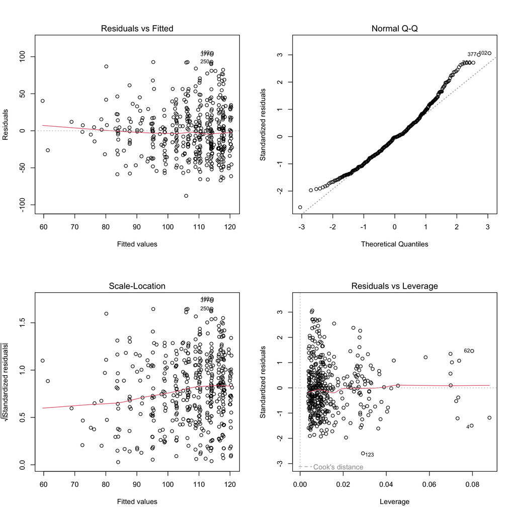

```r
par(mfrow = c(2,2)); plot(big_model); par(mfrow = c(1,1))
```

From these residual plots for the big model, there aren’t any obvious issues for our assumptions of linearity and constant variance. There is a slight right skew in the QQ plot, which may indicate an issue for normality, but the skew doesn’t seem very much and as such, doesn’t violate the assumption of normality. There are also no issues with points that are highly influential.

### 9.2.2 Residual Plots for the Small Model

We will now examine residual plots for our small model.

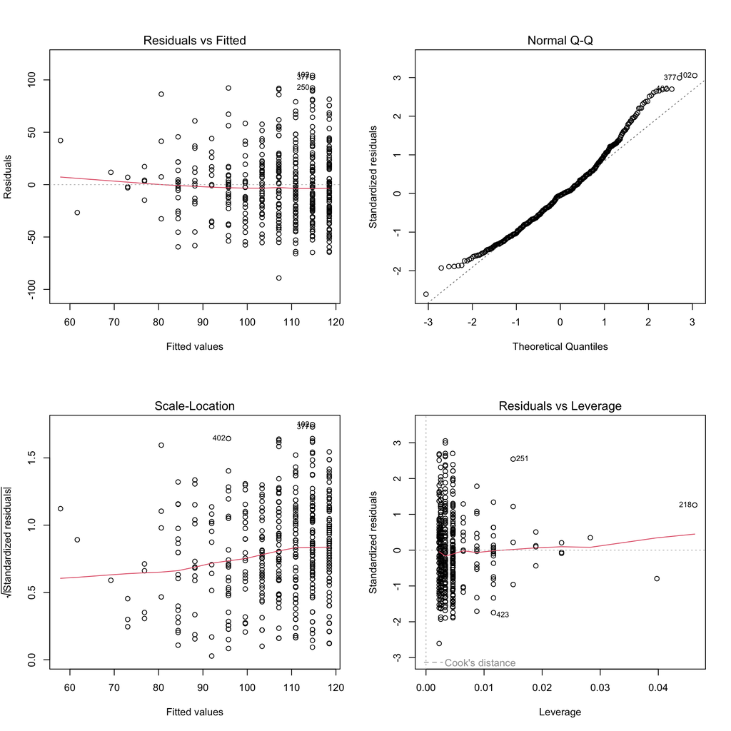

```r
par(mfrow = c(2,2)); plot(small_model); par(mfrow = c(1,1))
```

From these residual plots for the small model, there also aren’t any obvious issues for our assumptions of linearity and constant variance. Similarly, there is a slight right skew in the QQ plot, which may indicate an issue for normality, but the skew doesn’t seem very much and as such, doesn’t violate the assumption of normality. There are also no issues with points that are highly influential.

### 9.2.3 Does collinearity have a meaningful impact?

Since we have more than one predictor variable for our big model, we have to check for collinearity between them.

```r
car::vif(big_model)
```

```
             GVIF Df GVIF^(1/(2*Df))
rxdcount 1.033874  1        1.016796
alq170   1.023391  1        1.011628
whd020   1.025114  1        1.012479
smq040   1.031416  2        1.007763
```

We can see that we don’t have any issues as all GVIF values are below 5.

## 9.3 Comparing the Models

Based on various metrics to compare our big and small model, I currently believe that the smaller model is marginally better than the large one.

# 10 Model Validation

To validate our models, we will fit each one to our held out test data and see how they perform.

## 10.1 Calculating Prediction Errors

### 10.1.1 Big Model: Back-Transformation and Calculating Fits/Residuals

We will use augment() to get fitted values from our big model for the test data.

```r
big_aug <- augment(big_model, newdata = study_test) |>
  mutate(model = "big") |>
  select(seqn, model, everything())

big_aug
```

```
# A tibble: 189 × 9
     seqn model lbdldl rxdcount alq170 whd020 smq040 .fitted .resid
    <dbl> <chr>  <dbl>    <dbl>  <dbl>  <dbl> <fct>    <dbl>  <dbl>
 1 109330 big       67        3      0    140 3        110.   -43.1
 2 109379 big      102       10      0    185 3         83.8   18.2
 3 109580 big       54        1      1    147 2        117.   -63.2
 4 109608 big      128        4      0    118 3        106.    21.8
 5 109976 big       52        1      0    176 1        120.   -68.2
 6 109990 big       46        6      0    160 1        101.   -55.3
 7 110056 big       79        1      0    180 3        118.   -38.8
 8 110228 big      191        1      0    235 1        120.    70.5
 9 110232 big      118       10      1    284 1         86.6   31.4
10 110390 big      210        1      0    189 3        118.    92.1
# … with 179 more rows
```

### 10.1.2 Small Model: Back-Transformation and Calculating Fits/Residuals

Again, we will use augment() to get fitted values from our small model for the test data.

```r
small_aug <- augment(small_model, newdata = study_test) |>
  mutate(model = "small") |>
  select(seqn, model, everything())

small_aug
```

```
# A tibble: 189 × 9
     seqn model lbdldl rxdcount alq170 whd020 smq040 .fitted .resid
    <dbl> <chr>  <dbl>    <dbl>  <dbl>  <dbl> <fct>    <dbl>  <dbl>
 1 109330 small     67        3      0    140 3        111.   -43.9
 2 109379 small    102       10      0    185 3         84.4   17.6
 3 109580 small     54        1      1    147 2        118.   -64.5
 4 109608 small    128        4      0    118 3        107.    20.9
 5 109976 small     52        1      0    176 1        118.   -66.5
 6 109990 small     46        6      0    160 1         99.6  -53.6
 7 110056 small     79        1      0    180 3        118.   -39.5
 8 110228 small    191        1      0    235 1        118.    72.5
 9 110232 small    118       10      1    284 1         84.4   33.6
10 110390 small    210        1      0    189 3        118.    91.5
# … with 179 more rows
```

### 10.1.3 Combining the Results

To compare how each model performed in predicting `lbdldl` values, we will now create a new dataset with data from both of our augmented datasets.

```r
model_comp <- union(big_aug, small_aug) |>
  arrange(seqn, model)

model_comp
```

```
# A tibble: 378 × 9
     seqn model lbdldl rxdcount alq170 whd020 smq040 .fitted .resid
    <dbl> <chr>  <dbl>    <dbl>  <dbl>  <dbl> <fct>    <dbl>  <dbl>
 1 109330 big       67        3      0    140 3        110.   -43.1
 2 109330 small     67        3      0    140 3        111.   -43.9
 3 109379 big      102       10      0    185 3         83.8   18.2
 4 109379 small    102       10      0    185 3         84.4   17.6
 5 109580 big       54        1      1    147 2        117.   -63.2
 6 109580 small     54        1      1    147 2        118.   -64.5
 7 109608 big      128        4      0    118 3        106.    21.8
 8 109608 small    128        4      0    118 3        107.    20.9
 9 109976 big       52        1      0    176 1        120.   -68.2
10 109976 small     52        1      0    176 1        118.   -66.5
# … with 368 more rows
```

Based on this table, we can compare results on the surface between the two models. By looking at the raw fitted and residual values, it looks the models predicted very similar `lbdldl` values.

## 10.2 Visualizing the Predictions

We will now visualize our predicted `lbdldl` values with our observed `lbdldl` values for each model.

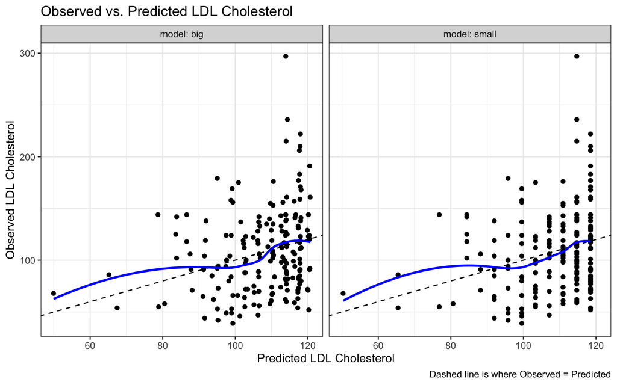

```r
ggplot(model_comp, aes(x = .fitted, y = lbdldl)) +
  geom_point() +
  geom_abline(slope = 1, intercept = 0, lty = "dashed") +
  geom_smooth(method = "loess", col = "blue", se = FALSE, formula = y ~ x) +
  facet_wrap( ~ model, labeller = "label_both") +
  labs(x = "Predicted LDL Cholesterol",
       y = "Observed LDL Cholesterol",
       title = "Observed vs. Predicted LDL Cholesterol",
       caption = "Dashed line is where Observed = Predicted")
```

The two graphs look more or less the same, particularly regarding the loess smooth curve. Both of these models don’t have many points along with dashed line, indicating that most predicted `lbdldl` values aren’t very similar to the observed values. The only noticeable difference is with the small model, the predicted values look like they are placed on vertical lines but that is because there is only one predictor variable (`rxdcount`) used in the model.

## 10.3 Summarizing the Errors

Now we will get the errors for each model using mean absolute prediction error, root mean squared prediction error, and maximum absolute error as our metrics.

```r
model_comp |> group_by(model) |>
  dplyr::summarise(n = n(),
                   MAPE = mean(abs(.resid)),
                   RMSPE = sqrt(mean(.resid^2)),
                   max_error = max(abs(.resid)))
```

```
# A tibble: 2 × 5
  model     n  MAPE RMSPE max_error
  <chr> <int> <dbl> <dbl>     <dbl>
1 big     189  30.9  39.6      183.
2 small   189  31.0  39.6      182.
```

With this table, we can see that both of the models’ performance is nearly identical. The smaller model outperforms the bigger model in terms of RMSPE and max_error by 0.002 and 0.801 respectively. The bigger model outperforms the smaller model in terms of MAPE by 0.098. These metrics allow us to see that the models’ residual values as a whole were almost the same.

### 10.3.1 Identify the largest errors

Here, we identify the patient in both models that has the largest absolute residual value.

```r
big_largest <- big_aug |>
  filter(abs(.resid) == max(abs(.resid)))

small_largest <- small_aug |>
  filter(abs(.resid) == max(abs(.resid)))

bind_rows(big_largest, small_largest)
```

```
# A tibble: 2 × 9
    seqn model lbdldl rxdcount alq170 whd020 smq040 .fitted .resid
   <dbl> <chr>  <dbl>    <dbl>  <dbl>  <dbl> <fct>    <dbl>  <dbl>
1 117059 big      297        2      0    145 3         114.   183.
2 117059 small    297        2      0    145 3         115.   182.
```

We can see that for both models, the patient’s `seqn` is 117059 and has an observed `lbdldl` of 297. The big model predicted a value of 113.9, corresponding to a residual value of 183.1. The small model predicted a value of 114.7, corresponding to a residual value of 182.3.

### 10.3.2 Validated R-square values

Validated $R^2$ values is something that we have to look at for each of our models, as it represents the amount of proportion of `lbdldl` variance accounted for by our predictor variables.

```r
cor(big_aug$lbdldl, big_aug$.fitted)^2
```

```
[1] 0.0574193
```

```r
cor(small_aug$lbdldl, small_aug$.fitted)^2
```

```
[1] 0.05762841
```

The big model has an $R^2$ value of 0.057 and the small model’s value is 0.058, which are effectively the same. Both of these values are lower than our training models where the big model had an $R^2$ of 0.098 and the smaller model had a value of 0.097.

## 10.4 Comparing the Models

I would select the smaller model here, on the basis of the similar performance in terms of the visualization of errors, and the small improvements in RMSPE and maximum prediction error, as well as validated $R^2$.

# 11 Discussion

## 11.1 Chosen Model

Considering how similarly the two models performed, model selection can go either way. On one hand, the smaller model can be better in certain scenarios because it’s only reliant on one predictor and has less predictors overall. This can help to both compare `rxdcount` and `lbdldl` more directly as well as have shorter model running times relative to the big model because it is less complex. The bigger model can be better because it includes more variables, which means that more aspects of a patient’s life is accounted for. This would mean that we can get a more holistic idea of how `lbdldl` is impacted by `rxdcount` along with the various predictors. Furthermore, it may be more representative for future observations as `lbdldl` is determined by much more than just `rxdcount`. I would choose the smaller model because of it’s simplicity and how my key predictor variable is the only predictor. This means that I can get a more direct comparison between how the the model predicts a patient’s LDL cholesterol based on the number of prescription medications take because no additional variables can impact the `lbdldl` prediction.

## 11.2 Answering My Question

From our two models, we are able to directly compare predicting `lbdldl` with just `rxdcount` and predicting `lbdldl` with `rxdcount`, `alq170`, `whd020`, and `smq040`. For the first part of our question, we can see that our smaller model with only `rxdcount` doesn’t accurately predict a patient’s `lbdldl`. Similarly, the big model doesn’t accurately predict a patient’s `lbdldl`, with an $R^2$ value that is essentially identical. With these two models, we can see that the addition of `alq170`, `whd020`, and `smq040` as predictors didn’t add any value relative to only using `rxdcount`, as all of our evaluation metrics led us to believe that the two models performed nearly the same.

## 11.3 Next Steps

My next step would be to use a better method to deal with missing values rather than only keeping samples that have complete data. Our dataset originally had 3,922 observations prior to filtering out complete cases and then only had 630 afterwards. With this much smaller dataset, the models couldn’t be trained as well because they have less observations to learn from, in turn likely decreasing model accuracy. Other possible methods that we could use to deal with missing values includes various ways of imputation. I think that for me, I would find the two most important variables for our big model using the original dataset. After that, I would remove observations that are missing values for either of the most important variables and then use those two values to impute other missing values.

## 11.4 Reflection

Something that I would’ve changed in my approach to study 2 with what I know now is the variables chosen as predictors. I should’ve checked to see if the predictor variables had at least some sort of correlation to our outcome variable `lbdldl`. Referring back to our scatterplot matrix, we can see that `alq170` and `whd020` have a correlation of ~0 with `lbdldl`, which indicates that there isn’t really a relationship between either of these variables and `lbdldl`. Furthermore, it looks like for `smq040` the `lbdldl` value distributions are pretty similar for each level. With these uncorrelated predictor variables, they didn’t make much of an impact in predicting LDL cholesterol values, which can be seen by our small model of just `rxdcount` performing nearly identical to our big model with all four predictor variables. By having different predictor variables, the big model could’ve performed better and there would’ve been a much more interesting comparison between my big and small model.